# **Домашнее задание №1 по многофакторному анализу (в группах)**

Ольга Мироненко

## **Постановка задачи: кратко**

К вам, как к биостатистикам, обратился исследователь, который изучает **влияние курения матери во время беременности на вес ребенка при рождении и на развитие осложнений во время родов**. Возможно, не самая новая и не самая актуальная проблема, но судить об этом – не наша задача :) Додумать, где может работать этот исследователь и почему его может интересовать эта тема, вы можете сами.

## **Что принёс исследователь?**

### 1. **DAG**

- Исследователь уже изучил специализированную литературу по своей и смежным темам (например, о влиянии курения матери на младенческую смертность). В некоторых статьях ему попадались картинки с направленными ациклическими графами (direct acyclic graphs, DAGs). В качестве примера он донёс до вас 2 из них: [эту](https://www.researchgate.net/publication/6855979_The_Birth_Weight_Paradox_Uncovered) и [эту](https://bmcpregnancychildbirth.biomedcentral.com/articles/10.1186/s12884-020-02981-1). Из первой он понял, что DAG может оказаться ему полезным, но не понял, как его составить правильно, поэтому в качестве основы взял DAG из второй статьи, обогатил его всем, что он узнал из других статей и из своего опыта, и
- Нарисовал вот такой DAG – Он старался! :)

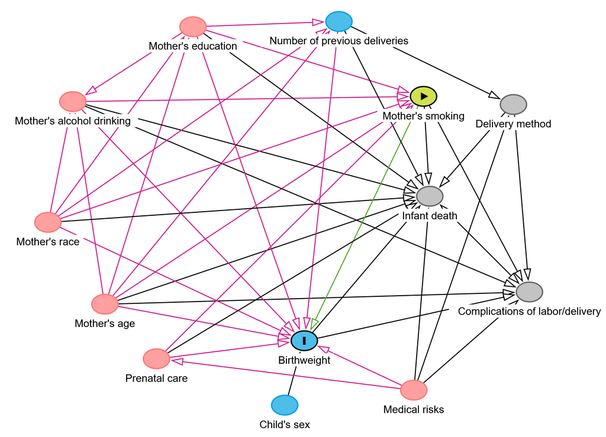

- И дал вам [ссылку на него в онлайн-приложении DAGitty](https://dagitty.net/dags.html?id=h5QiTU2u).

**Замечание 1**. **Приведенные статьи не являются обязательными к прочтению для выполнения задания, но могут оказаться довольно полезными**, в том числе для понимания того, что такое DAG, какие в нем бывают переменные, с точки зрения причинно-следственного вывода, и как это всё использовать (особенно первая статья; во второй можно также посмотреть структуру и принципы написания отдельных разделов для финального отчета).

**Замечание 2**. Немного про DAGи вам рассказывал **Артемий Охотин в лекции “Байесы и конфаундинг”**.

**Замечание 3**. Граф был отрисован в **приложении [DAGitty](https://www.dagitty.net/dags.html)**. На [этой страничке](https://dagitty.net/learn/) авторы приложения приводят ссылки на основные источники для более глубокого погружения в теоретические аспекты, а также на инструкции по использованию своего приложения.

- От вас не требуется изучать их все!
- Достаточно будет почитать то, что находится в разделе [DAG Terminology](https://dagitty.net/learn/graphs/index.html) и [Covariate roles in DAG](https://dagitty.net/learn/graphs/roles.html) – чтобы понимать принцип, по которому в графе те или иные показатели (узлы) или стрелки окрашиваются в определенный цвет и какой цвет какой роли показателя соответствует. Внизу по второй ссылке и интерактивчик небольшой для тренировки и закрепления есть. После этого советуем почитать [The Table 2 Fallacy](https://www.dagitty.net/learn/graphs/table2-fallacy.html) и выполнить интерактивные задания там.
- Может также пригодиться [подробный мануал](https://dagitty.net/manual-3.x.pdf) или [более краткий cheatsheet](https://dagitty.net/learn/primer/Dagitty-Cheat-Sheet.pdf) по использованию приложения.
- Кому больше заходит видео, можно посмотреть [это с теорией](https://www.youtube.com/watch?v=lRyG7zL9du8) и [это с примерами в DAGitty](https://www.youtube.com/watch?v=pJhU4fimHBQ).

**Замечание 4**. **Приложением пользоваться необязательно**, если вы по исходной картинке разберетесь с тем, что вам будет необходимо для выполнения задания, но, в целом, **оно полезно не только для отрисовки графа**, но и для понимания того:

- Какие показатели вам необходимо будет измерить и включить в свою многофакторную модель, чтобы выполнить деконфаундинг (“очистить” эффект интересующего вас воздействия на интересующий вас исход от вклада вмешивающихся переменных),
- Какие, наоборот, не нужно включать, чтобы не добавить смещения (например, коллайдеры),
- А какие пригодятся вам для оценки прямого (direct), а не полного (total) эффекта интересующего вас воздействия, если вдруг вам это будет необходимо.

**Замечание 5**. Обратите, пожалуйста, внимание на то, что исследователь хочет оценить воздействие курения и на вес ребенка, и на развитие осложнений во время родов. Это нужно будет делать в **двух разных моделях** (спойлер: с помощью линейной и логистической регрессии, соответственно).

- При этом на том DAGе, который вы видите на картинке и который по умолчанию открывается по ссылке в приложении, воздействие обозначено треугольником, похожим на кнопку Play (**▶**), – и это курение матери во время беременности, а исход – вертикальной чертой, похожей на заглавную **I** (**|**) – и это вес ребенка при рождении.
- Соответственно, когда вы при выполнении задания будете говорить о второй части исследовательской задачи, вам необходимо будет поменять исход на осложнения при родах. Для этого нужно, во-первых, кликнуть на текущий исход (Birthweight) и в меню слева сверху в разделе Variable убрать галочку около “outcome”, а во-вторых, кликнув на Complications…, эту галочку около “outcome”, наоборот, поставить.

**Замечание 6**. Вы уже поняли, что **в меню Variable можно задавать роли для показателей воздействия и исхода – аналогичным образом в нем можно отмечать в качестве “adjusted” те показатели, которые вы хотели бы включить в свою модель для исхода, помимо воздействия**.

- На самом деле еще до того, как вы это сделаете, приложение уже дает вам подсказку, на что нужно adjust’ить, чтобы получить несмещенную оценку эффекта для выбранного вами воздействия на выбранный вами исход (см. меню справа сверху, **раздел Causal effect identification**). В качестве упражнения вы можете выделить предлагаемые приложением переменные как “adjusted”, а потом попробовать подобавлять по одной к “adjusted” те, которые он не предложил, – и посмотреть, что изменится в его вердикте в разделе Causal effect identification.
- Ещё лучше при этом будет поупражняться в объяснении себе, от чего этот вердикт (Incorrectly или Correctly adjusted) зависит, и обсудить это с другими членам своей команды. Подсказка: для Incorrectly это может быть либо не включенный в модель конфаундер, либо включенный коллайдер, либо, при оценке total effect, включенный медиатор. Ваша задача – понимать, чем они друг от друга отличаются.

### 2. **Данные**

- Исследователь провел **кросс-секционное исследование** и уже собрал данные в табличку (они содержатся в файле *HW_data.xlsx*)[^1]. Конечно, лучше было бы, если бы он обратился к вам до этого, но это жизнь! Зато вам очень повезло с другими качествами исследователя: во-первых, он явно (в прошлом?) социолог и имеет основания утверждать, что это репрезентативная выборка из той популяции, которая его интересует (тут можете пофантазировать сами, что это может быть за популяция такая), а во-вторых, данные он честно уже проверил и почистил, поэтому ошибок в них быть не должно. Это, конечно, ближе к фантастике, чем к реальной жизни, и даже после всех подобных заверений вы все равно должны будете всё проверить, но, может, это хотя бы немного снизит ужас от объема задания и информации для изучения, который к этому пункту у вас уже мог накопиться.
- И спецификацию к данным (лейблы для переменных и категорий) исследователь вам прислал (в файле *HW_codebook.xlsx*).

## **Собственно, ваше домашнее задание**

Итак, **ваша задача в рамках всего цикла домашних заданий по многофакторному анализу – оценить общий (total) эффект курения матери во время беременности в отношении *среднего* веса ребенка при рождении и *вероятности* развития осложнений во время родов**.

**Сравните эту формулировку с формулировкой задачи, которую перед вами поставил исследователь**. Обратите внимание на то, что здесь мы вам уже *немного* помогли в переводе этой задачи на статистический язык:

- Мы указали, что необходимо будет оценить именно общий эффект, т.е. суммарный прямой и через медиаторы, если они вдруг будут.
- Мы указали, в отношении каких именно параметров распределения исходов необходимо будет этот эффект оценить: не просто вес ребенка, а его *среднее значение*, не просто осложнения во время родов, а *вероятность* их развития. В реальности выбор параметра производится в диалоге с исследователем: в зависимости от того, что его интересует, исходя из задачи исследования и того, как это чаще всего делается в его доменной области.
- Помогли мы вам *немного* – потому, что дальше вам еще предстоит проделать некоторую работу для т.н. операционализации задачи, т.е. перевода задачи на статистический язык.
1. Изложите своими словами то, **как вы поняли задачу от исследователя**.
- Чем, на ваш взгляд, может быть ему полезен ответ на поставленный исследовательский вопрос.
- **Рекомендуется отразить это в п.1 (Постановка задачи) в .rmd.**
2. На основе ваших знаний из курса по доказательной медицине и первой лекции по регрессионному анализу:
- Обоснуйте, **почему для решения задачи, поставленной исследователем вам нужна именно каузальная, а не предсказательная модель**.
- Какие **систематические ошибки** могут искажать оценку тех эффектов, которые вам необходимо будет оценить, и почему? Какие из них связаны с дизайном исследования? Какие вы сможете решить с помощью имеющихся данных и доступных вам средств? Какие ошибки, скорее всего, останутся нерешенными и какие это будет накладывать ограничения на тот вывод, который вы сможете сделать по результатам всего анализа?
- Если бы вы могли предотвратить или скорректировать все предполагаемые вами систематические ошибки, то **какой результат вы ожидали бы увидеть** (иными словами, как курение матери во время беременности может сказываться на среднем весе ребенка при рождении и вероятности осложнений во время родов)? Почему? Предположите или обоснуйте это на основе ваших знаний/ литературных источников.
- **Рекомендуется отразить это в п.1 (Постановка задачи) в .rmd.**
3. **Отдельно для *каждой* части исследовательского вопроса** на основе предоставленного вам исследователем DAGа **укажите, какую роль (с точки зрения соответствующего причинно-следственного вывода) играет *каждая* переменная, которую исследователь отразил в своем DAGe**.
- Условие: вы доверяете исследователю как специалисту в его доменной области, поэтому **ни исправлять, ни дополнять предложенный им DAG не нужно** (например, добавлять/ удалять стрелки или узлы, менять направления стрелок). Единственное, что вы можете менять – это исход для каждой части исследовательского вопроса.
- Посмотрите предложенные выше источники по основам DAGов. Для каждой части исследовательского вопроса отдельно **поделите переменные на воздействие, исход, конфаундеры, коллайдеры, медиаторы и нейтральные переменные**. Для конфаундеров, которые напрямую не влияют на воздействие и/или исход, посмотрите, как устроен их каузальный путь. Аналогично для коллайдеров, которые не являются прямыми наследниками воздействия и/или исхода. И для медиаторов, которые не являются прямыми наследниками воздействия.
- **Представьте итоговый набор переменных, которые необходимо будет включить в каждую модель для деконфаундинга**. Если возможно несколько альтернативных вариантов наборов, перечислите их. Как вы думаете, почему DAGitty может предлагать вам не все переменные, которые отмечены на графе как конфаундеры? Что будет, если включить их все?
- **Необязательная БОНУСНАЯ часть (для тех, кому интересно)**: может ли быть такое, что исследователь представил на своем графе не все возможные конфаундеры? Может быть, вы даже знаете/ предполагаете, что это за переменные могут быть? Как вы думаете, насколько существенным может быть для ожидаемых результатов неучет этих переменных?
- **Ответы на все эти вопросы рекомендуется представить в пп.2.4.2 и 2.5.2 (Материалы и методы / Анализ конечной точки 1 / DAG и отбор ковариат модели и Материалы и методы / Анализ конечной точки 2 / DAG и отбор ковариат модели, соответственно) в .rmd. Часть из вопросов решает сугубо учебные задачи и является избыточной, с точки зрения самого исследования, однако мы просим привести здесь ответы на все из них.**
4. Вы должны сами принять решение, **каким образом вы будете измерять *курение матери во время беременности*** по имеющимся данным, но вы должны обосновать свой выбор. Аналогично – с теми **ковариатами**, которые вы решили включить в свою модель. Это могут быть количественные или категориальные показатели, для категориальных показателей вы можете использовать как исходную (как в данных) категоризацию, так и объединять какие-то категории в одну (с соответствующим обоснованием) – на ваше усмотрение.
- Помните о возможных недостатках категоризации (см. [лекцию Алексея Глазкова во втором сезоне Разрушителей статистических мифов](https://bioinf.me/stat_myths)), но оставайтесь в рамках вашего понимания задачи.
- **Описание и обоснование выбора подходов к измерению ключевых показателей рекомендуется представить в пп.2.4.3 и 2.5.3 (Материалы и методы / Анализ конечной точки 1 / Измерение ключевых показателей и Материалы и методы / Анализ конечной точки 2 / Измерение ключевых показателей, соответственно) в .rmd.**
5. **Проведите необходимый эксплораторный анализ** представленных исследователем данных, обращая особое внимание на то, что имеет непосредственное отношение к решению задачи.
- Используйте навыки, полученные вами на курсах по визуализации, табличному представлению описательных статистик, анализу парных ассоциаций.
- *Замечание*: На этом шаге мы не проверяем какие-либо гипотезы. Наша задача – описать массив данных в контексте задачи и, возможно, заметить какие-то особенности, которые потом помогут со спецификацией модели.
- Сопроводите представленные результаты эксплораторного анализа комментариями относительно каких-либо особенностей, которые вы увидели в данных.
- *Замечание*: учитывайте, что вам потом необходимо будет оценивать многофакторные модели.
- **Перечень описательных статистик, которые будут представлены по каждому типу переменных, можно перечислить в п.2.3 (Материалы и методы / Описательные статистики) в .rmd.**
- **Сами описательные статистики и ключевые результаты эксплораторного анализа необходимо представить в разделе 3.1 (Результаты / Описательная статистика и эксплораторный анализ) в .rmd. При необходимости объемные графики и таблицы можно разместить в Приложении, дав на них в тексте соответствующую ссылку, не забывая о том, что они все равно должны быть аккуратными и читаемыми, а главное, служить какой-то задаче в вашем отчете.**

**Формат сдачи задания**:

Ссылка на приватный репозиторий GitHub, в котором, помимо необходимых данных, должны быть:

1. .rmd файл с вашими рассуждениями и ответами на поставленные вопросы, а также чанками с кодом для эксплораторного анализа и вывода его результатов. **Шаблон .rmd** с заданной под финальный отчет структурой вам будет предоставлен вместе с этим заданием. Заметьте, что в следующих заданиях вы будете его постепенно дополнять.
2. .html файл с отчетом, сформированный по .rmd из п.1.

Пожалуйста, посмотрите общую информацию по домашним заданиям по многофакторному анализу с требованиями для .rmd и .html для финального отчета – будет замечательно, если вы будете их придерживаться, начиная с выполнения ДЗ №1.

К репозиторию должен быть доступ у преподавателей: Евгения Бакина, Ольги Мироненко и Матвея Славенко.

**ДЗ №1 (в группах) может выложить в свой репозиторий один из участников команды, и он/она же – прислать ссылку на этот репозиторий в гугл-классе.** Обратите, пожалуйста, внимание, что следующие задания будут индивидуальными, поэтому для следующих заданий у вас у каждого должен быть индивидуальный приватный репозиторий под этот проект, но .rmd и .html должны будут по-прежнему содержать всё то, что сделает команда в первой части – в эту часть вы можете вносить свои, индивидуальные, изменения, если посчитаете нужным.

**Дедлайн – 23.11.2025 23:59 мск.**

**Сдавшие ДЗ до дедлайна получат фидбек от преподавателя в гугл-классе. По результатам фидбека можно будет внести исправления в эту часть ДЗ при сдаче последующих частей**.

**P.S. Бонусные задания не являются обязательными, выполняются по желанию, дают возможность заработать дополнительные баллы** (если вдруг вы их потеряете на каких-то других этапах выполнения задания), **в случае их невыполнения вы ничего не теряете**

[^1]: В действительности эти данные – случайная выборка, сделанная преподавателями из когорты детей, родившихся в США в 1990 г. (данные [National Center for Health Statistics (NCHS)](https://www.cdc.gov/nchs/data_access/vitalstatsonline.htm)) специально для этого задания. [Здесь](https://ftp.cdc.gov/pub/Health_Statistics/NCHS/Dataset_Documentation/DVS/cohortlinked/LinkCO91Guide.pdf) можно посмотреть полную документацию к основному массиву данных. В целом, для выполнения задания это несущественная информация – просто для понимания того, почему спецификация на английском :)